# DGE_EGTAvsYPD_37C_WT_delta_thesis

Rachael Murray

2025-03-04

# Summary

Differential Gene Expression +EGTA vs -EGTA in WT and +EGTA vs -EGTA in flc1∆ at 37°C samples, using DESeq2

## EGTA vs YPD in WT at 37°C

### Load count data from shared script load_count_data.Rmd

# Load and organise count data

`load_count_data.Rmd` is just to load and organise the raw count data in R, as well as loading libraries for data analysis. Other scripts can just run this one instead of duplicating code, especially scripts for differential gene expression analysis.

This runs *after* `QC_PCA.Rmd`, which does the organisation. This just loads the organised counts from the file `results/summaries/counts_bysamplecode.txt`.

## Load the organised counts

```r
counts_all <-
  here::here("results", "summaries", "counts_bysamplecode.txt") %>%
  readr::read_tsv(comment = "#",
                  col_types = "ciiiiiiiiiiiiiiiiiiiiiiiiiiiiiii")   %>%
  magrittr::set_rownames(.$Gene)
counts_all
```

```
## # A tibble: 6,795 × 32
##    Gene       Length WT_30_Y_1 WT_30_Y_2 WT_30_Y_3 FL_30_Y_1 FL_30_Y_2 FL_30_Y_3
##  * <chr>       <int>     <int>     <int>     <int>     <int>     <int>     <int>
##  1 CNAG_00002   1027       322       378       346       310       309       174
##  2 CNAG_00003   2397        19        43        27        54        52        33
##  3 CNAG_00004   3424        94        80        83       102        94        65
##  4 CNAG_00005   2162       462       399       385       378       344       310
##  5 CNAG_00006   1450      1019      1533      1256      1505      1359       778
##  6 CNAG_00007   2294       471       703       579       476       407       284
##  7 CNAG_00008   4351       141       226       206       272       259       164
##  8 CNAG_00009   1794       160       162       187       323       250       171
##  9 CNAG_00010   3879       195       199       242       362       272       159
## 10 CNAG_00011   2037        85       117       114       162       139        81
## # ℹ 6,785 more rows
## # ℹ 24 more variables: WT_37_Y_1 <int>, WT_37_Y_2 <int>, WT_37_Y_3 <int>,
## #   FL_37_Y_1 <int>, FL_37_Y_2 <int>, FL_37_Y_3 <int>, WT_37_C_1 <int>,
## #   WT_37_C_2 <int>, WT_37_C_3 <int>, FL_37_C_1 <int>, FL_37_C_2 <int>,
## #   FL_37_C_3 <int>, WT_37_E_1 <int>, WT_37_E_2 <int>, WT_37_E_3 <int>,
## #   FL_37_E_1 <int>, FL_37_E_2 <int>, FL_37_E_3 <int>, WT_37_CE_1 <int>,
## #   WT_37_CE_2 <int>, WT_37_CE_3 <int>, FL_37_CE_1 <int>, FL_37_CE_2 <int>, …
```

## Load the sample sheet

```r
sample_sheet <-
  here::here("input", "experiment",
             "CryptoRNAseqFLC1SampleKey.csv") %>%
  readr::read_csv(comment = "#", col_types = "ccccccc") %>%
  dplyr::mutate(Condition = stringr::str_sub(SampleName,start = 1L, end = -3L)) %>%
  dplyr::transmute(SampleID = as_factor(SampleID),
                   SampleName = as_factor(SampleName),
                   Condition = as_factor(Condition),
                   FLC1 = factor(FLC1, levels = c("delta", "WT")),
                   Temperature = factor(Temperature, levels = c("30", "37")),
                   Media = as_factor(Media),
                   BioRep = as_factor(BioRep))

sample_sheet
```

```
## # A tibble: 30 × 7
##    SampleID SampleName Condition FLC1  Temperature Media BioRep
##    <fct>    <fct>      <fct>     <fct> <fct>       <fct> <fct>
##  1 1        WT_30_Y_1  WT_30_Y   WT    30          YPD   1
##  2 2        WT_30_Y_2  WT_30_Y   WT    30          YPD   2
##  3 3        WT_30_Y_3  WT_30_Y   WT    30          YPD   3
##  4 4        FL_30_Y_1  FL_30_Y   delta 30          YPD   1
##  5 5        FL_30_Y_2  FL_30_Y   delta 30          YPD   2
##  6 6        FL_30_Y_3  FL_30_Y   delta 30          YPD   3
##  7 7        WT_37_Y_1  WT_37_Y   WT    37          YPD   1
##  8 8        WT_37_Y_2  WT_37_Y   WT    37          YPD   2
##  9 9        WT_37_Y_3  WT_37_Y   WT    37          YPD   3
## 10 10       FL_37_Y_1  FL_37_Y   delta 37          YPD   1
## # ℹ 20 more rows
```

## Load H99 Gene information

```r
gene_info_df <-
  here::here("input", "annotation",
             "H99_geneinfo_FungiDB59.txt") %>%
  readr::read_tsv(comment = "#")  %>%
  dplyr::rename(gene = GeneID, geneName = GeneName)
```

### DESeq on a subset of data, only WT in YPD

```r
sample_sheet_EGTAvsYPD_WT_37C <-
  dplyr::filter(sample_sheet,
                FLC1 == "WT",
                Media %in% c("YPD", "YPD_EGTA"),
                Temperature == "37"
  )

dds_EGTAvsYPD_WT_37C <-
  DESeqDataSetFromMatrix(
    countData = counts_all %>%
      dplyr::select(sample_sheet_EGTAvsYPD_WT_37C$SampleName) %>%
      magrittr::set_rownames(counts_all$Gene),
    colData = sample_sheet_EGTAvsYPD_WT_37C,
    design = ~ Media) %>%
  DESeq()
```

```
## factor levels were dropped which had no samples
```

```r
dds_EGTAvsYPD_WT_37C
```

```
## class: DESeqDataSet
## dim: 6795 6
## metadata(1): version
## assays(4): counts mu H cooks
## rownames(6795): CNAG_00002 CNAG_00003 ... CNAG_14001 CNAG_14002
## rowData names(22): baseMean baseVar ... deviance maxCooks
## colnames(6): WT_37_Y_1 WT_37_Y_2 ... WT_37_E_2 WT_37_E_3
## colData names(8): SampleID SampleName ... BioRep sizeFactor
```

```r
results(dds_EGTAvsYPD_WT_37C)
```

```
## log2 fold change (MLE): Media YPD EGTA vs YPD
## Wald test p-value: Media YPD EGTA vs YPD
## DataFrame with 6795 rows and 6 columns
##             baseMean log2FoldChange     lfcSE      stat      pvalue       padj
##            <numeric>      <numeric> <numeric> <numeric>   <numeric>  <numeric>
## CNAG_00002  349.2983     -0.1210063  0.153829 -0.786628 0.431499592 0.63315373
## CNAG_00003   34.6625      0.0516286  0.309583  0.166768 0.867552489 0.93373253
## CNAG_00004   93.1127     -0.0774996  0.205448 -0.377223 0.706007822 0.83724311
## CNAG_00005  524.6388     -0.1074553  0.146859 -0.731693 0.464356215 0.66037995
## CNAG_00006 1275.0138     -0.4078557  0.116681 -3.495474 0.000473221 0.00420336
## ...              ...            ...       ...       ...         ...        ...
## CNAG_08027 260.34564       0.168300  0.156707  1.073978   0.2828323   0.490813
## CNAG_08028  89.44174       0.196280  0.213663  0.918639   0.3582845   0.567705
## CNAG_08029  82.44289      -0.396222  0.225732 -1.755278   0.0792118   0.208381
## CNAG_14001 319.50423      -0.152948  0.148375 -1.030821   0.3026247   0.512962
## CNAG_14002   1.06325       1.289858  1.737328  0.742438   0.4578219         NA
```

```r
resultsNames(dds_EGTAvsYPD_WT_37C)
```

```
## [1] "Intercept"             "Media_YPD_EGTA_vs_YPD"
```

```r
deseq_df_EGTAvsYPD_WT_37C <-
  biobroom::tidy.DESeqDataSet(dds_EGTAvsYPD_WT_37C) %>%
  dplyr::filter(term == "Media_YPD_EGTA_vs_YPD") %>%
  dplyr::left_join(gene_info_df,
                   by = "gene") %>%
  dplyr::select(gene,
                geneName,
                baseMean,
                log2FC = estimate,
                stderror,
                padj = p.adjusted)
```

### List DEGs most UP in EGTA vs YPD in WT at 37°C

We cut off at 2x changes with 5% FDR here.

```r
# Make data frames of DEGs up and down, arranged by log2FC
DEGdf_EGTA_up2x_FDR5 <-
  dplyr::filter(deseq_df_EGTAvsYPD_WT_37C,
                log2FC > 1, padj < 0.05) %>%
  dplyr::arrange(desc(log2FC))
print(DEGdf_EGTA_up2x_FDR5, n = 20)
```

```
## # A tibble: 104 × 6
##    gene       geneName baseMean log2FC stderror      padj
##    <chr>      <chr>       <dbl>  <dbl>    <dbl>     <dbl>
##  1 CNAG_00979 CTR4     13295.     6.94    0.162 0
##  2 CNAG_05278 <NA>        13.6    6.26    1.24  1.52e-  5
##  3 CNAG_01653 CIG1       161.     4.74    0.290 3.35e- 57
##  4 CNAG_02775 BIM1     10868.     4.10    0.121 1.53e-248
##  5 CNAG_01560 <NA>         2.88   3.95    1.46  3.31e-  2
##  6 CNAG_00876 FRE7       443.     3.73    0.166 6.12e-109
##  7 CNAG_02893 <NA>        10.7    3.11    0.715 2.44e-  4
##  8 CNAG_07334 FRE4      1774.     3.01    0.116 9.58e-145
##  9 CNAG_02083 SIT2        90.0    3.01    0.258 1.08e- 28
## 10 CNAG_03498 FRE201      77.1    2.74    0.267 2.62e- 22
## 11 CNAG_03746 <NA>        27.8    2.72    0.428 1.85e-  8
## 12 CNAG_05662 PTP1        19.6    2.72    0.493 1.74e-  6
## 13 CNAG_07784 <NA>        60.4    2.30    0.284 9.95e- 14
## 14 CNAG_05075 <NA>         5.46   2.25    0.844 3.60e-  2
## 15 CNAG_07701 CTR1      1206.     2.15    0.170 1.42e- 33
## 16 CNAG_05387 <NA>       145.     2.09    0.200 4.97e- 23
## 17 CNAG_06524 FRE3         8.28   2.09    0.674 1.28e-  2
## 18 CNAG_02839 <NA>        58.9    2.08    0.271 2.55e- 12
## 19 CNAG_00749 <NA>         8.47   1.97    0.681 2.11e-  2
## 20 CNAG_04092 <NA>        11.6    1.97    0.604 8.15e-  3
## # ℹ 84 more rows
```

Print the top 20 *named* DEGs

```r
DEGdf_EGTA_up2x_FDR5 %>%
  dplyr::filter(!is.na(geneName)) %>%
  print(n = 20)
```

```
## # A tibble: 33 × 6
##    gene       geneName baseMean log2FC stderror      padj
##    <chr>      <chr>       <dbl>  <dbl>    <dbl>     <dbl>
##  1 CNAG_00979 CTR4     13295.     6.94    0.162 0
##  2 CNAG_01653 CIG1       161.     4.74    0.290 3.35e- 57
##  3 CNAG_02775 BIM1     10868.     4.10    0.121 1.53e-248
##  4 CNAG_00876 FRE7       443.     3.73    0.166 6.12e-109
##  5 CNAG_07334 FRE4      1774.     3.01    0.116 9.58e-145
##  6 CNAG_02083 SIT2        90.0    3.01    0.258 1.08e- 28
##  7 CNAG_03498 FRE201      77.1    2.74    0.267 2.62e- 22
##  8 CNAG_05662 PTP1        19.6    2.72    0.493 1.74e-  6
##  9 CNAG_07701 CTR1      1206.     2.15    0.170 1.42e- 33
## 10 CNAG_06524 FRE3         8.28   2.09    0.674 1.28e-  2
## 11 CNAG_04388 SOD2      1970.     1.87    0.135 3.12e- 40
## 12 CNAG_05377 ITR3        14.0    1.65    0.498 7.08e-  3
## 13 CNAG_05381 ITR3C       17.7    1.58    0.451 4.01e-  3
## 14 CNAG_00815 SIT1       583.     1.52    0.128 9.56e- 30
## 15 CNAG_02958 CFO2       346.     1.49    0.152 3.83e- 20
## 16 CNAG_06242 CFT1       577.     1.44    0.133 7.65e- 25
## 17 CNAG_01446 HSP12     1866.     1.40    0.133 2.04e- 23
## 18 CNAG_06821 FRE2       201.     1.35    0.188 8.91e- 11
## 19 CNAG_06241 CFO1      1529.     1.33    0.116 1.03e- 27
## 20 CNAG_00699 LPI15      572.     1.33    0.154 1.39e- 15
## # ℹ 13 more rows
```

### List DEGs most DOWN in EGTA vs YPD in WT at 37°C

```r
# Make data frames of DEGs up and down, arranged by log2FC
DEGdf_EGTA_down2x_FDR5 <-
  dplyr::filter(deseq_df_EGTAvsYPD_WT_37C,
                log2FC < -1, padj < 0.05) %>%
  dplyr::arrange(log2FC)
print(DEGdf_EGTA_down2x_FDR5, n = 20)
```

```
## # A tibble: 26 × 6
##    gene       geneName baseMean log2FC stderror     padj
##    <chr>      <chr>       <dbl>  <dbl>    <dbl>    <dbl>
##  1 CNAG_04469 <NA>         60.0  -4.04    0.400 1.47e-21
##  2 CNAG_03454 <NA>         51.4  -2.26    0.319 1.60e-10
##  3 CNAG_05602 PUT2       1655.   -2.11    0.137 2.31e-50
##  4 CNAG_04467 <NA>        182.   -1.71    0.183 1.60e-18
##  5 CNAG_06910 <NA>         10.0  -1.64    0.600 3.08e- 2
##  6 CNAG_01138 CCP1        669.   -1.59    0.126 1.78e-33
##  7 CNAG_06404 <NA>        146.   -1.49    0.180 3.12e-14
##  8 CNAG_02852 <NA>       4558.   -1.48    0.114 1.31e-35
##  9 CNAG_01019 SOD1       4319.   -1.45    0.148 2.48e-20
## 10 CNAG_02944 APH1         11.7  -1.44    0.540 3.68e- 2
## 11 CNAG_04470 <NA>         53.3  -1.43    0.277 8.47e- 6
## 12 CNAG_06556 <NA>         41.1  -1.42    0.301 5.72e- 5
## 13 CNAG_00306 MTN2         39.0  -1.41    0.335 4.33e- 4
## 14 CNAG_01883 GAT8         14.4  -1.35    0.485 2.82e- 2
## 15 CNAG_06557 <NA>         27.8  -1.34    0.356 1.86e- 3
## 16 CNAG_04999 <NA>         52.7  -1.20    0.271 1.90e- 4
## 17 CNAG_00716 <NA>      16199.   -1.15    0.158 3.70e-11
## 18 CNAG_07316 <NA>         34.9  -1.15    0.325 3.77e- 3
## 19 CNAG_03215 <NA>         63.5  -1.11    0.268 5.55e- 4
## 20 CNAG_05449 MTN1        304.   -1.10    0.151 4.30e-11
## # ℹ 6 more rows
```

Print the top 20 *named* DEGs

```r
DEGdf_EGTA_down2x_FDR5 %>%
  dplyr::filter(!is.na(geneName)) %>%
  print(n = 20)
```

```
## # A tibble: 7 × 6
##   gene       geneName baseMean log2FC stderror     padj
##   <chr>      <chr>       <dbl>  <dbl>    <dbl>    <dbl>
## 1 CNAG_05602 PUT2       1655.   -2.11    0.137 2.31e-50
## 2 CNAG_01138 CCP1        669.   -1.59    0.126 1.78e-33
## 3 CNAG_01019 SOD1       4319.   -1.45    0.148 2.48e-20
## 4 CNAG_02944 APH1         11.7  -1.44    0.540 3.68e- 2
## 5 CNAG_00306 MTN2         39.0  -1.41    0.335 4.33e- 4
## 6 CNAG_01883 GAT8         14.4  -1.35    0.485 2.82e- 2
## 7 CNAG_05449 MTN1        304.   -1.10    0.151 4.30e-11
```

### Volcano plot of DEGs

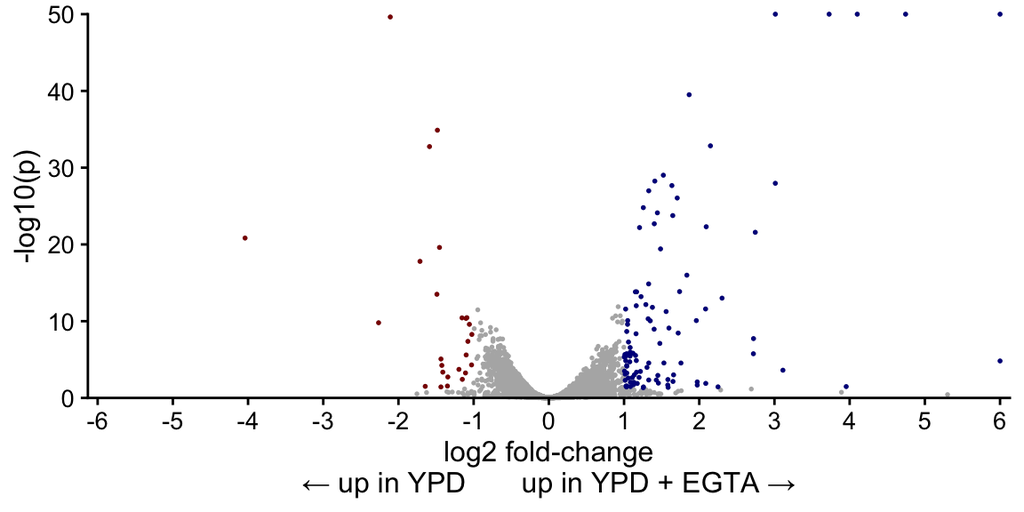

```r
volcano_EGTAvsYPD_WT_37C <-
  ggplot(data = deseq_df_EGTAvsYPD_WT_37C,
         aes(x = log2FC, y = -log10(padj)) ) +
  geom_point(size = 0.3, colour = "grey70") +
  geom_point(data = DEGdf_EGTA_up2x_FDR5,
             size = 0.3, colour = "darkblue") +
  geom_point(data = DEGdf_EGTA_down2x_FDR5,
             size = 0.3, colour = "darkred") +
  scale_y_continuous("-log10(p)",
                     limits = c(0,50), expand = c(0,0),
                     oob=scales::squish) +
  scale_x_continuous("log2 fold-change\n← up in YPD       up in YPD + EGTA →",
                     breaks = -6:6,
                     limits = c(-6,6), expand = c(0.01,0.01),
                     oob = scales::squish) +
  coord_cartesian(clip = "off")
volcano_EGTAvsYPD_WT_37C
```

### Write outputs to files

```r
deseq_df_EGTAvsYPD_WT_37C %>%
  dplyr::mutate(
    across(c(baseMean, log2FC, stderror), round, digits = 3)
  ) %>%
  dplyr::mutate(padj = signif(padj, digits = 4)) %>%
  write_tsv(file = here::here("results", "DEGs",
                              "deseq_df_EGTAvsYPD_WT_37C.txt"))
```

```r
DEGdf_EGTA_up2x_FDR5 %>%
  dplyr::pull(gene) %>%
  write_lines(file = here::here("results", "DEGs",
                            "deglist_EGTAvsYPD_WT_37C_up2x_FDR5.txt"))

DEGdf_EGTA_down2x_FDR5 %>%
  dplyr::pull(gene) %>%
  write_lines(file = here::here("results", "DEGs",
                            "deglist_EGTAvsYPD_WT_37C_down2x_FDR5.txt"))
```

## EGTA vs YPD in flc1∆ at 37°C

# DESeq on a subset of data, only delta in YPD

```r
sample_sheet_EGTAvsYPD_delta_37C <-
  dplyr::filter(sample_sheet,
                FLC1 == "delta",
                Media %in% c("YPD", "YPD_EGTA"),
                Temperature == "37"
  )

dds_EGTAvsYPD_delta_37C <-
  DESeqDataSetFromMatrix(
    countData = counts_all %>%
      dplyr::select(sample_sheet_EGTAvsYPD_delta_37C$SampleName) %>%
      magrittr::set_rownames(counts_all$Gene),
    colData = sample_sheet_EGTAvsYPD_delta_37C,
    design = ~ Media) %>%
  DESeq()
```

```
## factor levels were dropped which had no samples
```

```r
dds_EGTAvsYPD_delta_37C
```

```
## class: DESeqDataSet
## dim: 6795 6
## metadata(1): version
## assays(4): counts mu H cooks
## rownames(6795): CNAG_00002 CNAG_00003 ... CNAG_14001 CNAG_14002
## rowData names(22): baseMean baseVar ... deviance maxCooks
## colnames(6): FL_37_Y_1 FL_37_Y_2 ... FL_37_E_2 FL_37_E_3
## colData names(8): SampleID SampleName ... BioRep sizeFactor
```

```r
results(dds_EGTAvsYPD_delta_37C)
```

```
## log2 fold change (MLE): Media YPD EGTA vs YPD
## Wald test p-value: Media YPD EGTA vs YPD
## DataFrame with 6795 rows and 6 columns
##             baseMean log2FoldChange     lfcSE      stat     pvalue      padj
##            <numeric>      <numeric> <numeric> <numeric>  <numeric> <numeric>
## CNAG_00002  457.3367     -0.2660212 0.1182662 -2.249343  0.0244907 0.0507716
## CNAG_00003   63.3449     -0.0432687 0.2530731 -0.170973  0.8642448 0.9066914
## CNAG_00004  119.7996      0.2423870 0.1869185  1.296752  0.1947164 0.2881683
## CNAG_00005  707.8432     -0.1680785 0.1077492 -1.559906  0.1187821 0.1927354
## CNAG_00006 1662.6791     -0.1892153 0.0899463 -2.103646  0.0354093 0.0696019
## ...              ...            ...       ...       ...        ...       ...
## CNAG_08027 464.91723      0.3275282  0.124782  2.624808 0.00866978  0.020576
## CNAG_08028 137.85557      0.0521241  0.170681  0.305389 0.76007006  0.829771
## CNAG_08029  94.38387     -0.5786674  0.207948 -2.782749 0.00539005  0.013596
## CNAG_14001 441.10054     -0.1914201  0.127639 -1.499705 0.13369088  0.212733
## CNAG_14002   2.33502      0.5462058  1.142315  0.478157 0.63253866  0.723544
```

```r
resultsNames(dds_EGTAvsYPD_delta_37C)
```

```
## [1] "Intercept"             "Media_YPD_EGTA_vs_YPD"
```

```r
deseq_df_EGTAvsYPD_delta_37C <-
  biobroom::tidy.DESeqDataSet(dds_EGTAvsYPD_delta_37C) %>%
  dplyr::filter(term == "Media_YPD_EGTA_vs_YPD") %>%
  dplyr::left_join(gene_info_df,
                   by = "gene") %>%
  dplyr::select(gene,
                geneName,
                baseMean,
                log2FC = estimate,
                stderror,
                padj = p.adjusted)
```

## List DEGs most UP in EGTA vs YPD in delta at 37°C

We cut off at 2x changes with 5% FDR here.

```r
# Make data frames of DEGs up and down, arranged by log2FC
DEGdf_EGTA_up2x_FDR5 <-
  dplyr::filter(deseq_df_EGTAvsYPD_delta_37C,
                log2FC > 1, padj < 0.05) %>%
  dplyr::arrange(desc(log2FC))
print(DEGdf_EGTA_up2x_FDR5, n = 20)
```

```
## # A tibble: 432 × 6
##    gene       geneName baseMean log2FC stderror      padj
##    <chr>      <chr>       <dbl>  <dbl>    <dbl>     <dbl>
##  1 CNAG_01653 CIG1      3085.     8.73    0.251 1.49e-261
##  2 CNAG_04877 <NA>        23.9    4.17    0.599 4.45e- 11
##  3 CNAG_00091 <NA>      1140.     4.12    0.139 2.52e-189
##  4 CNAG_05278 <NA>        43.5    4.02    0.459 4.93e- 17
##  5 CNAG_05662 PTP1      1593.     3.94    0.157 7.36e-136
##  6 CNAG_07912 <NA>         7.57   3.91    1.00  3.62e-  4
##  7 CNAG_06109 <NA>      1057.     3.79    0.138 8.87e-162
##  8 CNAG_00984 <NA>       683.     3.65    0.132 1.17e-164
##  9 CNAG_05994 <NA>       987.     3.64    0.128 1.29e-175
## 10 CNAG_07784 <NA>       606.     3.59    0.166 2.25e-101
## 11 CNAG_01102 <NA>       837.     3.42    0.129 3.80e-152
## 12 CNAG_07874 <NA>        68.0    3.41    0.334 7.09e- 23
## 13 CNAG_04163 <NA>       427.     3.40    0.150 2.64e-110
## 14 CNAG_07869 <NA>        38.8    3.35    0.470 1.41e- 11
## 15 CNAG_05683 <NA>      1043.     3.31    0.120 2.45e-163
## 16 CNAG_04704 <NA>        74.3    3.24    0.342 7.22e- 20
## 17 CNAG_03398 ZIP2       205.     3.24    0.194 4.82e- 60
## 18 CNAG_03782 <NA>        72.7    3.20    0.323 1.47e- 21
## 19 CNAG_03408 <NA>       670.     3.18    0.121 2.77e-150
## 20 CNAG_04837 MLN1        93.5    3.17    0.290 3.65e- 26
## # ℹ 412 more rows
```

Print the top 20 *named* DEGs

```r
DEGdf_EGTA_up2x_FDR5 %>%
  dplyr::filter(!is.na(geneName)) %>%
  print(n = 20)
```

```
## # A tibble: 76 × 6
##    gene       geneName baseMean log2FC stderror      padj
##    <chr>      <chr>       <dbl>  <dbl>    <dbl>     <dbl>
##  1 CNAG_01653 CIG1       3085.    8.73   0.251  1.49e-261
##  2 CNAG_05662 PTP1       1593.    3.94   0.157  7.36e-136
##  3 CNAG_03398 ZIP2        205.    3.24   0.194  4.82e- 60
##  4 CNAG_04837 MLN1         93.5   3.17   0.290  3.65e- 26
##  5 CNAG_03772 HXS1        528.    2.95   0.339  6.52e- 17
##  6 CNAG_05785 STB4         46.9   2.68   0.348  2.23e- 13
##  7 CNAG_03572 OPS1        787.    2.55   0.125  1.56e- 90
##  8 CNAG_03910 ITR6       1072.    2.51   0.157  1.31e- 55
##  9 CNAG_02083 SIT2        212.    2.32   0.162  1.59e- 44
## 10 CNAG_00979 CTR4      12287.    2.30   0.131  4.07e- 67
## 11 CNAG_03346 BZP4        377.    2.21   0.181  8.71e- 33
## 12 CNAG_06291 FPD1        431.    2.15   0.176  1.34e- 32
## 13 CNAG_05381 ITR3C       168.    2.01   0.211  7.58e- 20
## 14 CNAG_00531 ENA1       1745.    2.00   0.117  2.49e- 63
## 15 CNAG_00871 CLR3        191.    1.98   0.164  9.09e- 32
## 16 CNAG_01341 ISP3        393.    1.93   0.134  2.30e- 45
## 17 CNAG_00057 FPP1       2062.    1.84   0.0922 1.84e- 86
## 18 CNAG_06576 CAR1      12296.    1.78   0.0830 1.91e- 99
## 19 CNAG_06759 LPI1        176.    1.75   0.179  4.94e- 21
## 20 CNAG_03498 FRE201      336.    1.73   0.193  9.75e- 18
## # ℹ 56 more rows
```

## List DEGs most DOWN in EGTA vs YPD in delta at 37°C

```r
# Make data frames of DEGs up and down, arranged by log2FC
DEGdf_EGTA_down2x_FDR5 <-
  dplyr::filter(deseq_df_EGTAvsYPD_delta_37C,
                log2FC < -1, padj < 0.05) %>%
  dplyr::arrange(log2FC)
print(DEGdf_EGTA_down2x_FDR5, n = 20)
```

```
## # A tibble: 89 × 6
##    gene       geneName baseMean log2FC stderror     padj
##    <chr>      <chr>       <dbl>  <dbl>    <dbl>    <dbl>
##  1 CNAG_02582 <NA>         2.53  -3.65   1.51   3.39e- 2
##  2 CNAG_07399 <NA>        53.2   -2.72   0.323  8.38e-16
##  3 CNAG_05357 <NA>        87.7   -2.39   0.247  1.08e-20
##  4 CNAG_04901 <NA>        99.4   -2.17   0.271  1.89e-14
##  5 CNAG_05602 PUT2      3638.    -2.10   0.102  1.64e-91
##  6 CNAG_04215 MET3      3102.    -1.96   0.471  1.42e- 4
##  7 CNAG_05037 <NA>         8.87  -1.85   0.652  1.18e- 2
##  8 CNAG_03980 <NA>        33.5   -1.84   0.347  7.60e- 7
##  9 CNAG_01500 <NA>        11.1   -1.71   0.594  1.04e- 2
## 10 CNAG_03007 <NA>     14482.    -1.69   0.0961 6.63e-67
## 11 CNAG_00306 MTN2        58.6   -1.66   0.280  2.79e- 8
## 12 CNAG_03168 <NA>      1264.    -1.62   0.294  2.81e- 7
## 13 CNAG_01506 <NA>       205.    -1.60   0.163  2.26e-21
## 14 CNAG_02048 PUT5       597.    -1.57   0.124  5.27e-35
## 15 CNAG_03672 <NA>      1126.    -1.56   0.115  2.15e-40
## 16 CNAG_05863 <NA>       438.    -1.48   0.161  9.21e-19
## 17 CNAG_06745 H3       11755.    -1.48   0.285  1.35e- 6
## 18 CNAG_00235 AMT1       181.    -1.47   0.171  2.55e-16
## 19 CNAG_01656 <NA>        73.0   -1.43   0.241  2.57e- 8
## 20 CNAG_06372 <NA>       531.    -1.43   0.129  7.73e-27
## # ℹ 69 more rows
```

Print the top 20 *named* DEGs

```r
DEGdf_EGTA_down2x_FDR5 %>%
  dplyr::filter(!is.na(geneName)) %>%
  print(n = 20)
```

```
## # A tibble: 18 × 6
##    gene       geneName baseMean log2FC stderror     padj
##    <chr>      <chr>       <dbl>  <dbl>    <dbl>    <dbl>
##  1 CNAG_05602 PUT2       3638.   -2.10    0.102 1.64e-91
##  2 CNAG_04215 MET3       3102.   -1.96    0.471 1.42e- 4
##  3 CNAG_00306 MTN2         58.6  -1.66    0.280 2.79e- 8
##  4 CNAG_02048 PUT5        597.   -1.57    0.124 5.27e-35
##  5 CNAG_06745 H3        11755.   -1.48    0.285 1.35e- 6
##  6 CNAG_00235 AMT1        181.   -1.47    0.171 2.55e-16
##  7 CNAG_03716 BLP6        173.   -1.21    0.161 1.02e-12
##  8 CNAG_02870 MET7        522.   -1.17    0.118 1.04e-21
##  9 CNAG_06051 GAL1        305.   -1.17    0.137 3.38e-16
## 10 CNAG_06052 GAL7        157.   -1.16    0.178 9.01e-10
## 11 CNAG_07448 DUR3         56.5  -1.11    0.270 1.67e- 4
## 12 CNAG_00697 UGE1        948.   -1.11    0.116 6.56e-20
## 13 CNAG_02270 MET2        177.   -1.08    0.204 7.60e- 7
## 14 CNAG_05086 URM1        447.   -1.08    0.132 6.29e-15
## 15 CNAG_03984 YCH1        397.   -1.06    0.164 1.10e- 9
## 16 CNAG_04452 RSM18       988.   -1.05    0.117 6.39e-18
## 17 CNAG_01721 HEM3        987.   -1.02    0.126 1.21e-14
## 18 CNAG_02099 FAS1       6548.   -1.01    0.141 7.35e-12
```

## Volcano plot of DEGs

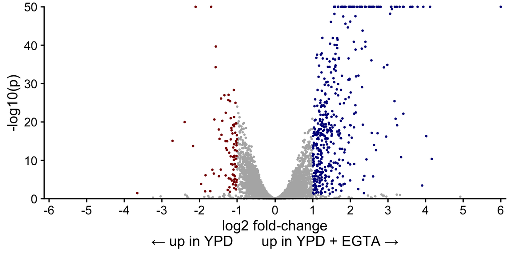

```r
volcano_EGTAvsYPD_delta_37C <-
  ggplot(data = deseq_df_EGTAvsYPD_delta_37C,
         aes(x = log2FC, y = -log10(padj)) ) +
  geom_point(size = 0.3, colour = "grey70") +
  geom_point(data = DEGdf_EGTA_up2x_FDR5,
             size = 0.3, colour = "darkblue") +
  geom_point(data = DEGdf_EGTA_down2x_FDR5,
             size = 0.3, colour = "darkred") +
  scale_y_continuous("-log10(p)",
                     limits = c(0,50), expand = c(0,0),
                     oob=scales::squish) +
  scale_x_continuous("log2 fold-change\n← up in YPD       up in YPD + EGTA →",
                     breaks = -6:6,
                     limits = c(-6,6), expand = c(0.01,0.01),
                     oob = scales::squish) +
  coord_cartesian(clip = "off")
volcano_EGTAvsYPD_delta_37C
```

## Write outputs to files

```r
deseq_df_EGTAvsYPD_delta_37C %>%
  dplyr::mutate(
    across(c(baseMean, log2FC, stderror), round, digits = 3)
  ) %>%
  dplyr::mutate(padj = signif(padj, digits = 4)) %>%
  write_tsv(file = here::here("results", "DEGs",
                              "deseq_df_EGTAvsYPD_delta_37C.txt"))

DEGdf_EGTA_up2x_FDR5 %>%
  dplyr::pull(gene) %>%
  write_lines(file = here::here("results", "DEGs",
                            "deglist_EGTAvsYPD_delta_37C_up2x_FDR5.txt"))

DEGdf_EGTA_down2x_FDR5 %>%
  dplyr::pull(gene) %>%
  write_lines(file = here::here("results", "DEGs",
                            "deglist_EGTAvsYPD_delta_37C_down2x_FDR5.txt"))
```